# 12.8 Efficient

## 12.8.2 Regularization: the 'top-down' approach to capacity tuning

*Regularization* techniques for capacity tuning leverage precisely this overfitting-optimization connection, and in general work by *preventing the complete minimization of a cost function associated with a high capacity `model`*. In other words, with regularization techniques in general we use a high capacity `model` and tune its parameters to indirectly encourage a good validation fit by preventing complete minimization of its associated cost function (and thus preventing overfitting to the training data). Contrary to boosting techniques, where we started 'from the bottom' and built up a more flexible `model` piece-by-piece by adding single feature transformations to it, regularization starts 'from the top' - the 'top' being a high capacity `model` - and tempers its capacity by imperfectly minimizing its corresponding cost function. This is somewhat of an *indirect* way of getting at a good overall fitting `model` - since what we are doing is directly preventing overfiting to training data.

> Contrary to boosting techniques, where we started 'from the bottom' and built up a flexible `model` piece-by-piece by adding single feature transformations to it, regularization starts 'from the top' - the 'top' being a high capacity `model` - and tempers its capacity by imperfectly minimizing its corresponding cost function.

Regularization can be performed a variety of ways, but in general there are two basic categories of strategies which we will discuss: *early stopping* and the addition of a *simple capacity-blunting function to the cost*.

## 12.8.3 Early stopping

Here the idea is to literally *stop* the optimization procedure *early*, before reaching a minimum / overfitting occurs. This is done by measuring validation error *during optimization*, and (roughly speaking) halting the procedure when validation error is minimal.

As with any form of capacity-tuning, our ideal is to find a `model` that provides the *lowest possible error on the validation set*. With early-stopping we do this by *stopping* the minimization of our cost function (which is measuring *training error*) when *validation error* reaches its lowest point. The basic idea is illustrated in the figure below. In the left panel we show a prototypical nonlinear regression dataset, and in the middle the cost function of a high capacity `model` shown figuratively in two dimensions. As we begin a run of a local optimization method we measure both the training error (provided by the cost function we are minimizing) as well as validation error at each step of the procedure - as shown in the right panel. We try to halt the procedure when the validation error has reached its lowest point.

[figure not shown]

**Figure 2:** *(left panel) A prototypical nonlinear regression dataset, (middel panel) a figurative illustration of the cost associated with a high capacity model, and the measurment of training / validation error at each step of a local optimization procedure. With *early stopping* we make a run of a local optimization procedure and measure both the training and validation error at each step. We try to halt the procedure when the validation error reaches its lowest value, with the corresponding set of weights providing our high capacity `model` with the least chance of overfitting our training data (and hopefully providing a good fit to the entire dataset).*

There are a number of important engineering details associated with making an effective early-stopping procedure, these include.

- **When is validation error really at its lowest?** While generally speaking validation error decreases at the start of an optimization run and eventually increases (making somewhat of a 'U' shape) it can certainly fluctuate up and down during optimization, so it is not all together obvious *when the validation error has indeed reached its lowest point*. To deal with this peculiarity often in practice a reasonable engineering choice is made as to when to stop based on how long it has been since the validation error has *not* decreased.
- **Large (local optimization) steps are to be avoided.** The idea with early stopping is to measure training / validation error often as an optimization procedure makes progress, so that the procedure can be halted when validation error is low. If one uses a local optimization procedure that takes *very large steps* - like e.g., Newton's method or a stochastic / mini-batch first order approach - optimization can quickly lead to weights that overfit the training data (in other words a set of weights that provide minimal validation error can be skipped over entirely). Thus when employing early stopping one needs to use a local optimization method with moderate-lengthed steps.
- **Validation error should be measured often.** Validation error should be measured frequently during the minimization process in order to determine a validation error minimizing set of weights. When employing a mini-batch / stochastic first order method validation error should be measured *several times per eopch* to avoid taking too large of steps without measuring validation error (and perhaps skipping over error minimizing weights entirely).

Below we show a few examples employing the early stopping regularization strategy.

#### Example 1. Early stopping of a prototypical regression dataset

Below we plot a prototypical nonlinear regression dataset. We will use early stopping regularization to fine tune the capacity of a `model` consisting of $10$ `tanh` neural network universal approximators.

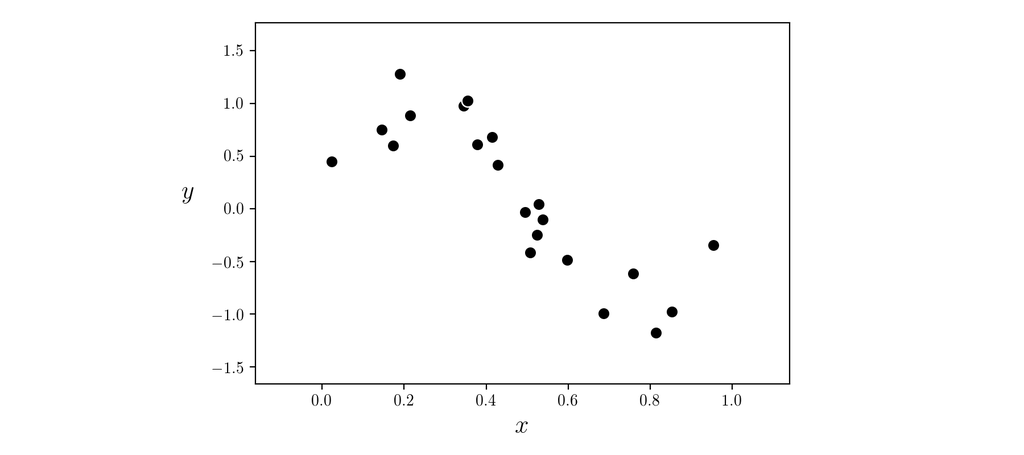

Below we illustrate a large number of gradient descent steps to tune our high capacity `model` for this dataset. As you move the slider left to right you can see the resulting fit at each highlighted step of the run in the original dataset (top left), training (bottom left), and validation data (bottom right). Moving the slider to where the validation error is lowest provides - for this training / validation split of the original data - a fine nonlinear model for the entire dataset.

[figure not shown]

#### Example 2. Early stopping of a prototypical classification dataset

Below we plot a prototypical nonlinear classification dataset. We will use early stopping regularization to fine tune the capacity of a `model` consisting of $5$ `tanh` neural network universal approximators.

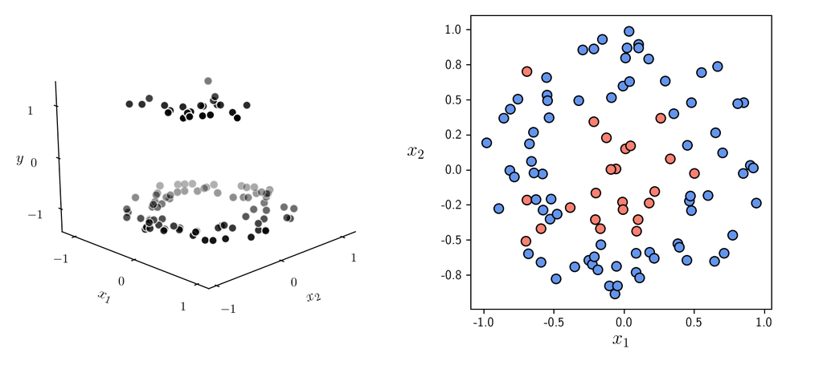

Below we illustrate a large number of gradient descent steps to tune our high capacity `model` for this dataset. As you move the slider left to right you can see the resulting fit at each highlighted step of the run in the original dataset (top left), training (bottom left), and validation data (bottom right). Moving the slider to where the validation error is lowest provides - for this training / validation split of the original data - a fine nonlinear model for the entire dataset.

[figure not shown]

## 12.8.4 Adding a simple, capacity blunting function to the cost

By adding a simple function to the cost function we change its shape, and in particular *change the location of its global minima*. Since the global minima of the adjusted cost function do not allign with those of the original cost, the adjusted cost can then be completely minimized with less fear of overfitting to the training data.

[figure not shown]